# iX Project - Group 2 - Q1(b)

Wiki: https://github.com/neilrankinza/ix_cape_town_2019_project/wiki

Build a machine learning model to: 1. Predict who is likely to be in work (in survey 1) so that they can intervene at ‘baseline’ 2. Predict who is likely to work for more than 6 months

# Understand the data

```r
head(data)
```

```
## # A tibble: 6 x 22
##    unid survey_date_mon… survey_num gender dob        province working
##   <dbl> <date>                <dbl> <chr>  <date>     <chr>    <lgl>
## 1 41964 2018-06-01                1 Female 1992-02-01 <NA>     TRUE
## 2 41964 2018-11-01                2 Female 1992-02-01 <NA>     TRUE
## 3 15241 2016-03-01                1 Female 1988-11-01 <NA>     TRUE
## 4 33702 2016-04-01                1 Male   1991-04-01 <NA>     TRUE
## 5 33702 2016-08-01                2 Male   1991-04-01 <NA>     FALSE
## 6 33702 2016-12-01                3 Male   1991-04-01 <NA>     FALSE
## # … with 15 more variables: job_start_date <date>, job_leave_date <date>,
## #   company_size <chr>, monthly_pay <chr>, volunteer <chr>,
## #   leadershiprole <chr>, peoplelive <chr>, peoplelive_15plus <chr>,
## #   numchildren <dbl>, numearnincome <chr>, anygrant <lgl>,
## #   anyhhincome <lgl>, financial_situation_now <chr>,
## #   financial_situation_5years <chr>, givemoney_yes <lgl>
```

```r
head(cft)
```

```
##    unid cft_score
## 1 41964         4
## 2 41964         4
## 3 15241         4
## 4 33702         5
## 5 33702         5
## 6 33702         5
```

```r
head(com)
```

```
##    unid com_score
## 1 41964         4
## 2 41964         4
## 3 15241         5
## 4 33702         5
## 5 33702         5
## 6 33702         5
```

```r
head(grit)
```

```
##    unid grit_score
## 1 41964          4
## 2 41964          9
## 3 15241          3
## 4 33702          2
## 5 33702          2
## 6 33702          0
```

```r
head(num)
```

```
##    unid num_score
## 1 68158         6
## 2 68536         3
## 3 33026         2
## 4 33026         2
## 5 33026         2
## 6 33026         2
```

```r
head(opt)
```

```
##    unid opt_score
## 1 41964        NA
## 2 41964        NA
## 3 15241         7
## 4 33702         3
## 5 33702        -5
## 6 33702        -1
```

```r
summary(data)
```

```
##       unid        survey_date_month      survey_num       gender
##  Min.   :     2   Min.   :2016-02-01   Min.   :1.000   Length:83270
##  1st Qu.: 25429   1st Qu.:2016-11-01   1st Qu.:1.000   Class :character
##  Median : 50430   Median :2017-07-01   Median :1.000   Mode  :character
##  Mean   : 50614   Mean   :2017-07-03   Mean   :1.637
##  3rd Qu.: 75531   3rd Qu.:2018-03-01   3rd Qu.:2.000
##  Max.   :102524   Max.   :2018-11-01   Max.   :9.000
##
##       dob               province          working
##  Min.   :1942-08-01   Length:83270       Mode :logical
##  1st Qu.:1990-05-01   Class :character   FALSE:63409
##  Median :1992-10-01   Mode  :character   TRUE :19861
##  Mean   :1992-06-07
##  3rd Qu.:1994-11-01
##  Max.   :2018-07-01
##  NA's   :166
##  job_start_date       job_leave_date       company_size
##  Min.   :2000-09-01   Min.   :2011-01-01   Length:83270
##  1st Qu.:2016-03-01   1st Qu.:2016-09-15   Class :character
##  Median :2016-11-01   Median :2017-03-06   Mode  :character
##  Mean   :2016-09-03   Mean   :2017-03-10
##  3rd Qu.:2017-06-01   3rd Qu.:2017-09-20
##  Max.   :2018-12-01   Max.   :2018-11-08
##  NA's   :57215        NA's   :64560
##  monthly_pay         volunteer         leadershiprole
##  Length:83270       Length:83270       Length:83270
##  Class :character   Class :character   Class :character
##  Mode  :character   Mode  :character   Mode  :character
##
##
##
##
##   peoplelive        peoplelive_15plus   numchildren    numearnincome
##  Length:83270       Length:83270       Min.   :0.00    Length:83270
##  Class :character   Class :character   1st Qu.:0.00    Class :character
##  Mode  :character   Mode  :character   Median :0.00    Mode  :character
##                                        Mean   :0.54
##                                        3rd Qu.:1.00
##                                        Max.   :3.00
##                                        NA's   :32167
##   anygrant       anyhhincome     financial_situation_now
##  Mode :logical   Mode :logical   Length:83270
##  FALSE:44461     FALSE:34773     Class :character
##  TRUE :31140     TRUE :40828     Mode  :character
##  NA's :7669      NA's :7669
##
##
##
##  financial_situation_5years givemoney_yes
##  Length:83270               Mode :logical
##  Class :character           FALSE:27647
##  Mode  :character           TRUE :22778
##                             NA's :32845
##
##
##
```

There are a lot of strange occurrences in the data

1. There is a codependency between peoplelive, peoplelive_15plus, numchildren and numearnincome. However, the data does not always seem to match up / make sense. For example, unid 690 is living with more than 15 people, and 8 in the household are earning income, but she did not fill in the number of members above 15 years of age. Meanwhile there is 1 child in the household. So, there are definitely members above 15 years of age, but we can’t easily impute the data.
2. Sometimes, peoplelive is less than numchildren - are these children not living at home? We do not know. Insight: Define terms used. Also, perform data validation to ensure logical responses (and reject illogical ones) - applies only for digital survey collection.
3. Sometimes, numearnincome indicated they lived alone, but peoplelive is more than 0. Consider unid 624 and 393 where this happened (there are more examples of this.)
4. Does numearnincome include the survey respondent? Even for working individuals, there are cases of the number being 0, which means some people are interpreting it to not include themselves. However, (e.g. unid 6336), numearnincome is 1, while peoplelive (excludes respondent) is 0. So the person earning income is himself. So the data is not consistently collected due to different interpretations.

Insight: Clearly define all terms used in survey questions to avoid ambiguity.

5. There are some people who are not currently working (based on the job_leave_date being before survey date) but working is True.

```r
data = arrange(data, unid)
```

# Split into work and no work groups

```r
data.work = data %>% filter(working==T) %>% select(-working)
data.nowork = data %>% filter(working==F)
```

# Cleanup

## Handling NAs in job_start_date and/or job_leave_date

1. If job_start_date is NA, remove row

At this point, all rows have a valid job_start_date

2. If job_leave_date is NA, we assume he is still working at the date of survey, hence replace job_leave_date with survey_date_month

```r
data.work$job_leave_date = as_date(ifelse(is.na(data.work$job_leave_date), data.work$survey_date_month, data.work$job_leave_date))
```

## Parsing peoplelive column

Some of the data entries are “0: I live alone” or “more than 15” etc, so they have to be parsed.

Do data clipping, by assuming “more than 15” is just 15.

```r
data.work <- data.work %>%
        mutate(peoplelive = parse_number(as.character(peoplelive))) %>%
        mutate(peoplelive_15plus = parse_number(as.character(peoplelive_15plus))) %>%
        mutate(numearnincome = parse_number(as.character(numearnincome)))
```

# Feature Engineering

1. Based on job_start_date and job_leave_date, create a column daysWorked, which gives the number of days worked

```r
data.work$daysWorked = as.Date(as.character(data.work$job_leave_date), format="%Y-%m-%d")-
                  as.Date(as.character(data.work$job_start_date), format="%Y-%m-%d") + 1
```

2. Based on daysWorked, create a column modeThanSixMths indicating whether the person has worked more than 6 months

```r
data.work$moreThanSixMths = ifelse(data.work$daysWorked >= 180, T, F)
```

3. Based on date of birth (dob) and survey_date_month, create column age_at_survey (and round to the nearest integer)

```r
data.work <- data.work %>%
 mutate(age_at_survey = interval(dob, survey_date_month)/years(1)) %>%
 mutate(age_at_survey = round(age_at_survey))
```

4. Parse the text from the financial situation columns, and create a column fin_situ_change that gives us the expected change in financial situation

```r
data.work <- data.work %>%
 mutate(fin_situ_now = parse_number(as.character(financial_situation_now))) %>%
 mutate(fin_situ_future = parse_number(as.character(financial_situation_5years))) %>%
 mutate(fin_situ_change = fin_situ_future - fin_situ_now)
```

Finally, let’s remove the redundant data we’ve already used to engineer features

```r
data.work = data.work %>% select(-job_start_date ,-job_leave_date, -dob, -financial_situation_now, -financial_situation_5years)
```

# Working with incomplete data

Check the number of NAs in every column, and calculate percentage of na’s in column

```r
na_count = sapply(data.work, function(y) sum(length(which(is.na(y)))))
na_count = data.frame(na_count)
dim(na_count)
```

```
## [1] 22  1
```

```r
# create column from index
names <- rownames(na_count)
# nullify index
rownames(na_count) <- NULL
na_count <- cbind(names,na_count)

na_count = mutate(na_count, percentageNA = 100*na_count/dim(data.work)[1])
na_count = arrange(na_count, desc(percentageNA))
na_count
```

```
##                names na_count percentageNA
## 1       company_size    14155  88.98038723
## 2        monthly_pay    14155  88.98038723
## 3  peoplelive_15plus    13000  81.71988936
## 4           province     8528  53.60824742
## 5      numearnincome     7924  49.81141564
## 6       fin_situ_now     5081  31.93990445
## 7    fin_situ_future     5081  31.93990445
## 8    fin_situ_change     5081  31.93990445
## 9      givemoney_yes     4877  30.65753080
## 10       numchildren     4726  29.70832286
## 11         volunteer     4668  29.34372643
## 12    leadershiprole     4668  29.34372643
## 13        peoplelive     4665  29.32486799
## 14          anygrant     1556   9.78124214
## 15       anyhhincome     1556   9.78124214
## 16     age_at_survey       20   0.12572291
## 17            gender        2   0.01257229
## 18              unid        0   0.00000000
## 19 survey_date_month        0   0.00000000
## 20        survey_num        0   0.00000000
## 21        daysWorked        0   0.00000000
## 22   moreThanSixMths        0   0.00000000
```

As we can see, company_size and monthly_pay are about 90% NAs. However, these are likely very important in determining whether a person is likely to stay at their job (for instance, if you’re paid well, you’re incentivised to stay on and work hard.) So, we will want to impute the data for this.

First, we’ll fill in the rest of the columns, making some assumptions along the way.

## Removal of columns

Remove peoplelive_15plus because it is 80% incomplete and does not add much because we already have numearnincome to quantify number of independents in the household

Also remove anyhhincome because it should all be TRUE given that data.work is a subset of the dataset that is working, so they should receive household income. Note that the data doesn’t all state TRUE so there was probably an issue with data collection here (in terms of clearly stating what household income means)

```r
data.work = select(data.work, -peoplelive_15plus, -anyhhincome)
```

## Removal of rows

Remove rows where gender is NA, because there are only 2 such datapoints Remove rows where age_at_survey is NA because there are only 20 such rows (out of almost 16000)

```r
data.work = filter(data.work, !is.na(data.work$gender))
data.work = filter(data.work, !is.na(data.work$age_at_survey))
```

## Assumptions

Assume that: 1. if givemoney_yes, volunteer, leadershiprole, anygrant is NA, it is no (FALSE) 2. if peoplelive, numchildren, numearnincome is NA, it is 0

```r
data.work$givemoney_yes = ifelse(is.na(data.work$givemoney_yes), FALSE, data.work$givemoney_yes)
data.work$volunteer = ifelse(is.na(data.work$volunteer), "No", data.work$volunteer)
data.work$leadershiprole = ifelse(is.na(data.work$leadershiprole), "No", data.work$leadershiprole)
data.work$anygrant = ifelse(is.na(data.work$anygrant), FALSE, data.work$anygrant)

data.work$peoplelive = ifelse(is.na(data.work$peoplelive), 0, data.work$peoplelive)
data.work$numchildren = ifelse(is.na(data.work$numchildren), 0, data.work$numchildren)
data.work$numearnincome = ifelse(is.na(data.work$numearnincome), 0, data.work$numearnincome)
```

Visualise the relation between numearnincome and peoplelive

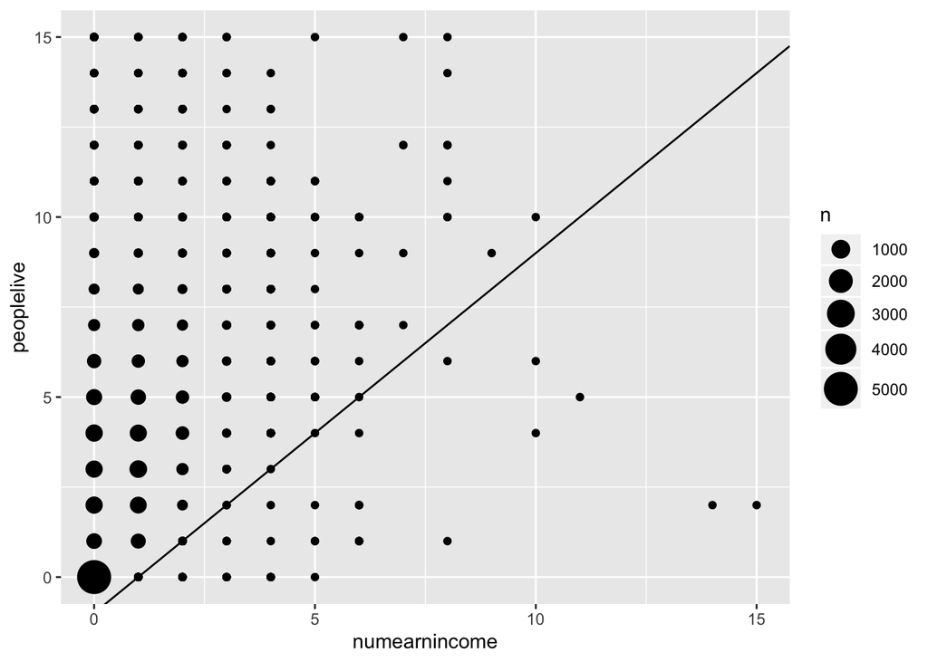

```r
ggplot(data.work, aes(x=numearnincome, y=peoplelive)) + geom_point() + geom_count() + geom_abline(slope=1, intercept=-1)+scale_size_continuous(range = c(1, 8))
```

We will assume whether numearnincome include self or not by taking the most commonly used interpretation of the survey respondents. a = People who definitely assumed that numearnincome does not include self = people indicating 0 numearnincome.

b = People who definitely assumed that numearnincome include self = numearnincome exceeds peoplelive by 1 (people who lies on the line y=x-1 shown above).

From graph, a>b.

Hence we should assume that numearnincome does not include self and correct the data by deducting 1 from b’s numearnincome.

```r
data.work$numearnincome = ifelse(data.work$numearnincome - data.work$peoplelive == 1,data.work$numearnincome-1,data.work$numearnincome)
```

Now we can see that there are no datapoints lying on the line y=x-1

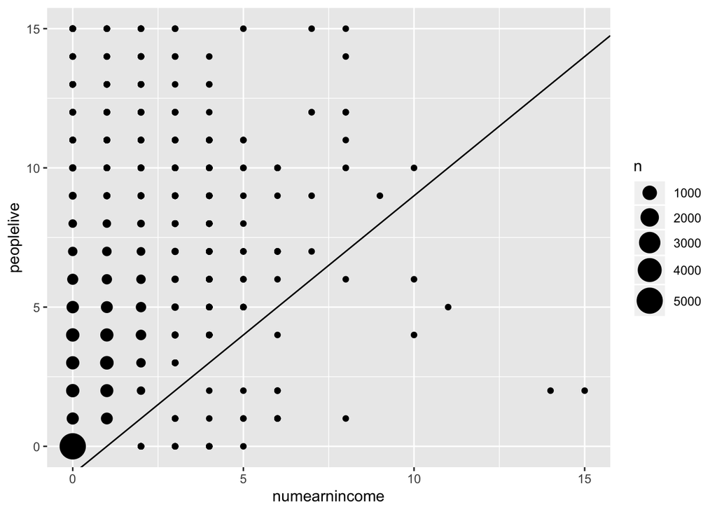

```r
ggplot(data.work, aes(x=numearnincome, y=peoplelive)) + geom_point() + geom_count() + geom_abline(slope=1, intercept=-1)+ scale_size_continuous(range = c(1, 8))
```

We then removed all rows of data in which numearnincome > peoplelive (datapoints below the line)

```r
data.work = filter(data.work, data.work$numearnincome <= data.work$peoplelive)
```

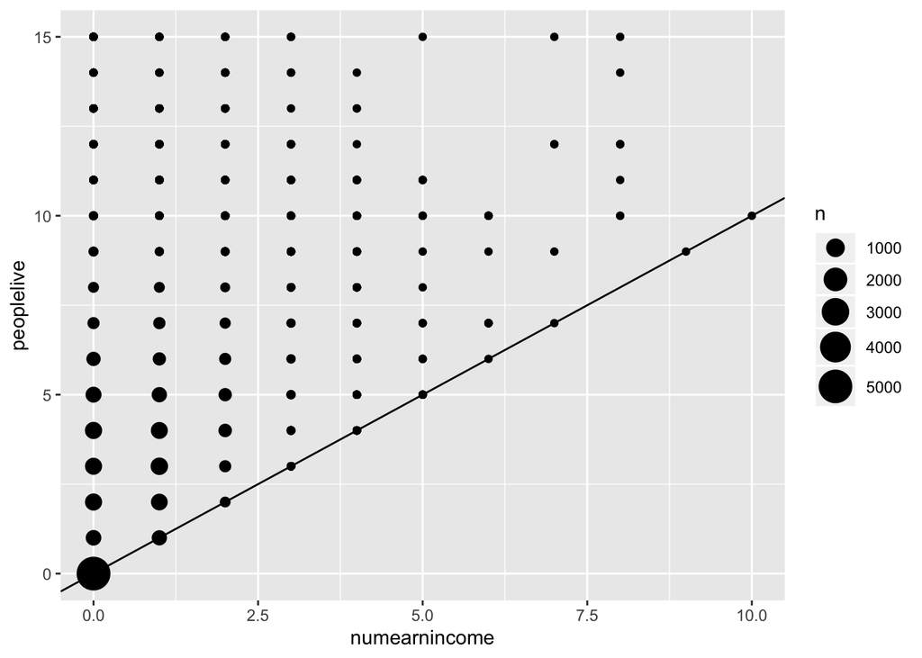

```r
ggplot(data.work, aes(x=numearnincome, y=peoplelive)) + geom_point() + geom_count() + geom_abline(slope=1, intercept=0)+ scale_size_continuous(range = c(1, 8))
```

Insight: BUT logically speaking since the survey is for people both working and not working, numearnincome was meant to contain self from surveyor’s perspective. But this was not made clear to the survey respondents.

Check the number of NAs in every column, and calculate percentage of na’s in column

```r
na_count = sapply(data.work, function(y) sum(length(which(is.na(y)))))
na_count = data.frame(na_count)
dim(na_count)
```

```
## [1] 20  1
```

```r
# create column from index
names <- rownames(na_count)
# nullify index
rownames(na_count) <- NULL
na_count <- cbind(names,na_count)

na_count = mutate(na_count, percentageNA = 100*na_count/dim(data.work)[1])
na_count = arrange(na_count, desc(percentageNA))
na_count
```

```
##                names na_count percentageNA
## 1       company_size    14104     89.06289
## 2        monthly_pay    14104     89.06289
## 3           province     8473     53.50467
## 4       fin_situ_now     5059     31.94620
## 5    fin_situ_future     5059     31.94620
## 6    fin_situ_change     5059     31.94620
## 7               unid        0      0.00000
## 8  survey_date_month        0      0.00000
## 9         survey_num        0      0.00000
## 10            gender        0      0.00000
## 11         volunteer        0      0.00000
## 12    leadershiprole        0      0.00000
## 13        peoplelive        0      0.00000
## 14       numchildren        0      0.00000
## 15     numearnincome        0      0.00000
## 16          anygrant        0      0.00000
## 17     givemoney_yes        0      0.00000
## 18        daysWorked        0      0.00000
## 19   moreThanSixMths        0      0.00000
## 20     age_at_survey        0      0.00000
```

## CLeaning the extra data (from the personality attribute tests)

After some exploration, we realised only opt has NAs

Clean opt because it has NAs

```r
opt = na.omit(opt)
```

Grit has multiple readings per individual, visualising this, which plots a graph of number of people against how many grit readings they have

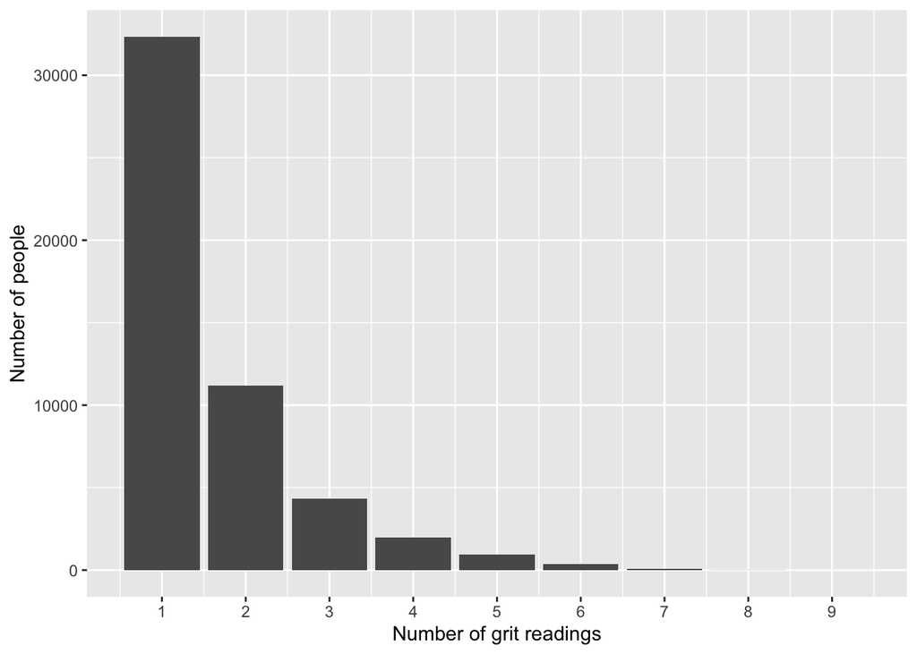

```r
grit_analysis  = group_by(grit, unid) %>% count() %>% group_by(n) %>% count()
ggplot(grit_analysis, aes(x=n,y=nn)) + geom_bar(stat="identity") + xlab("Number of grit readings") + ylab("Number of people") + scale_x_continuous(breaks = round(seq(min(grit_analysis$n), max(grit_analysis$n), by =1),1))
```

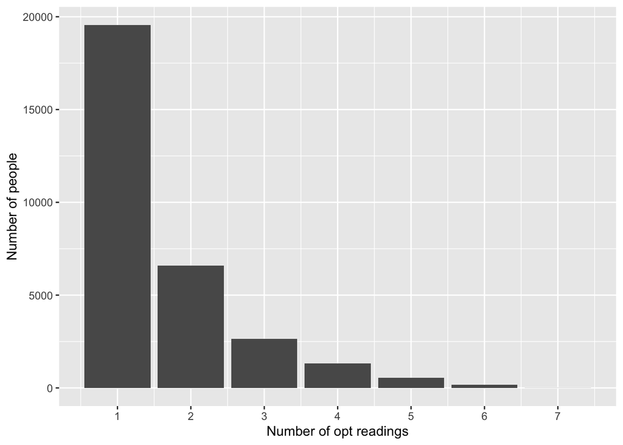

```r
opt_analysis  = group_by(opt, unid) %>% count() %>% group_by(n) %>% count()
ggplot(opt_analysis, aes(x=n,y=nn)) + geom_bar(stat="identity") + xlab("Number of opt readings") + ylab("Number of people") + scale_x_continuous(breaks = round(seq(min(opt_analysis$n), max(opt_analysis$n), by =1),1))
```

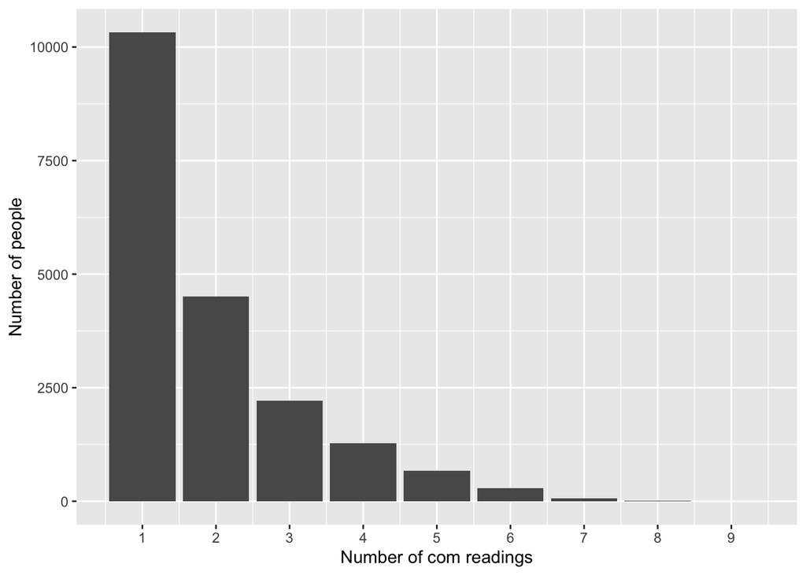

```r
com_analysis  = group_by(com, unid) %>% count() %>% group_by(n) %>% count()
ggplot(com_analysis, aes(x=n,y=nn)) + geom_bar(stat="identity") + xlab("Number of com readings") + ylab("Number of people") + scale_x_continuous(breaks = round(seq(min(com_analysis$n), max(com_analysis$n), by =1),1))
```

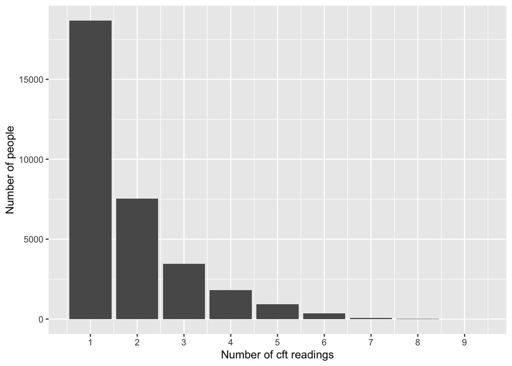

```r
cft_analysis  = group_by(cft, unid) %>% count() %>% group_by(n) %>% count()
ggplot(cft_analysis, aes(x=n,y=nn)) + geom_bar(stat="identity") + xlab("Number of cft readings") + ylab("Number of people") + scale_x_continuous(breaks = round(seq(min(cft_analysis$n), max(cft_analysis$n), by =1),1))
```

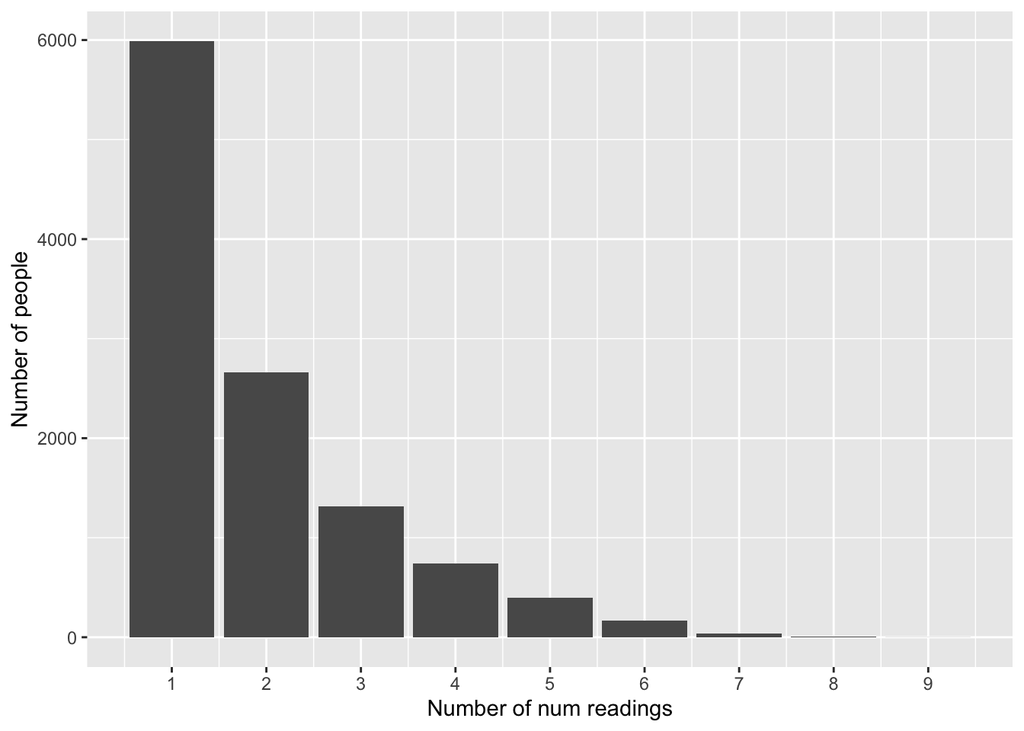

```r
num_analysis  = group_by(num, unid) %>% count() %>% group_by(n) %>% count()
ggplot(num_analysis, aes(x=n,y=nn)) + geom_bar(stat="identity") + xlab("Number of num readings") + ylab("Number of people") + scale_x_continuous(breaks = round(seq(min(num_analysis$n), max(num_analysis$n), by =1),1))
```

We will just take the mean to break ties

```r
grit_clean = group_by(grit,unid)  %>% summarise(mean_grit_score=mean(grit_score))
grit_clean$mean_grit_score = round(grit_clean$mean_grit_score)

com_clean = group_by(com,unid)  %>% summarise(mean_com_score=mean(com_score))
com_clean$mean_com_score = round(com_clean$mean_com_score)

opt_clean = group_by(opt,unid)  %>% summarise(mean_opt_score=mean(opt_score))
opt_clean$mean_opt_score = round(opt_clean$mean_opt_score)

cft_clean = group_by(cft,unid)  %>% summarise(mean_cft_score=mean(cft_score))
cft_clean$mean_cft_score = round(cft_clean$mean_cft_score)

num_clean = group_by(num,unid)  %>% summarise(mean_num_score=mean(num_score))
num_clean$mean_num_score = round(num_clean$mean_num_score)
```

merging the datasets

```r
data.work.merged = data.work %>% merge(opt_clean, by="unid", all.x=T) %>% merge(num_clean, by="unid", all.x=T) %>% merge(grit_clean,by="unid", all.x=T) %>% merge(cft_clean, by="unid", all.x=T) %>% merge(com_clean, by="unid", all.x=T)

summary(as.factor(data.work.merged$province))
```

```
##  Eastern Cape    Free state       Gauteng KwaZulu-Natal       Limpopo
##           528           100          4578          1012           246
##    Mpumalanga    North West Northern Cape  Western Cape          NA's
##           210           155            19           515          8473
```

remove the columns company_size and monthly_pay (removed)

```r
# data.work.merged = select(data.work.merged, -company_size, -monthly_pay)
```

Count the number of NAs per column

```r
na_count = sapply(data.work.merged, function(y) sum(length(which(is.na(y)))))
na_count = data.frame(na_count)
dim(na_count)
```

```
## [1] 25  1
```

```r
# create column from index
names <- rownames(na_count)
# nullify index
rownames(na_count) <- NULL
na_count <- cbind(names,na_count)

na_count = mutate(na_count, percentageNA = 100*na_count/dim(data.work.merged)[1])
na_count = arrange(na_count, desc(percentageNA))
na_count
```

```
##                names na_count percentageNA
## 1       company_size    14104     89.06289
## 2        monthly_pay    14104     89.06289
## 3     mean_num_score    10889     68.76105
## 4           province     8473     53.50467
## 5     mean_com_score     7512     47.43622
## 6       fin_situ_now     5059     31.94620
## 7    fin_situ_future     5059     31.94620
## 8    fin_situ_change     5059     31.94620
## 9     mean_opt_score     4210     26.58500
## 10    mean_cft_score     3140     19.82824
## 11              unid        0      0.00000
## 12 survey_date_month        0      0.00000
## 13        survey_num        0      0.00000
## 14            gender        0      0.00000
## 15         volunteer        0      0.00000
## 16    leadershiprole        0      0.00000
## 17        peoplelive        0      0.00000
## 18       numchildren        0      0.00000
## 19     numearnincome        0      0.00000
## 20          anygrant        0      0.00000
## 21     givemoney_yes        0      0.00000
## 22        daysWorked        0      0.00000
## 23   moreThanSixMths        0      0.00000
## 24     age_at_survey        0      0.00000
## 25   mean_grit_score        0      0.00000
```

Convert columns to factors

```r
cols = c("province","volunteer", "leadershiprole", "anygrant", "gender", "moreThanSixMths", "company_size", "monthly_pay")
data.work.merged[,cols] <- lapply(data.work.merged[,cols],as.factor)
```

## Impute the remaining missing data

```r
tempData <- mice(data.work.merged,m=5, meth='pmm',seed=500, maxit=2)
data.work.imp <- complete(tempData,1)
```

All NAs have been removed.

```r
na_count = sapply(data.work.imp, function(y) sum(length(which(is.na(y)))))
na_count = data.frame(na_count)
dim(na_count)
```

```
## [1] 25  1
```

```r
# create column from index
names <- rownames(na_count)
# nullify index
rownames(na_count) <- NULL
na_count <- cbind(names,na_count)

na_count = mutate(na_count, percentageNA = 100*na_count/dim(data.work.imp)[1])
na_count = arrange(na_count, desc(percentageNA))
na_count
```

```
##                names na_count percentageNA
## 1               unid        0            0
## 2  survey_date_month        0            0
## 3         survey_num        0            0
## 4             gender        0            0
## 5           province        0            0
## 6       company_size        0            0
## 7        monthly_pay        0            0
## 8          volunteer        0            0
## 9     leadershiprole        0            0
## 10        peoplelive        0            0
## 11       numchildren        0            0
## 12     numearnincome        0            0
## 13          anygrant        0            0
## 14     givemoney_yes        0            0
## 15        daysWorked        0            0
## 16   moreThanSixMths        0            0
## 17     age_at_survey        0            0
## 18      fin_situ_now        0            0
## 19   fin_situ_future        0            0
## 20   fin_situ_change        0            0
## 21    mean_opt_score        0            0
## 22    mean_num_score        0            0
## 23   mean_grit_score        0            0
## 24    mean_cft_score        0            0
## 25    mean_com_score        0            0
```

```r
# List of possible datasets for training

# data.work.imp

# data.work.rm.rows = select(na.omit(data.work.merged),  -survey_date_month, -survey_num, -unid)

#data.work.rm.columns = select(data.work.merged, -mean_num_score, -province, -mean_com_score, -fin_situ_now, -fin_situ_future, -fin_situ_change, -mean_opt_score, -mean_cft_score, -daysWorked, -survey_date_month, -survey_num, -unid)
```

Finalising the dataset

```r
# change the dataset accordingly to test

data.work.final = select(data.work.imp, -daysWorked, -survey_date_month, -survey_num, -unid)
```

## performing logistic regression

```r
df = data.work.final
# split the data

set.seed(5)
trainIndex <- createDataPartition(df$moreThanSixMths, p = .8,
                                  list = FALSE,
                                  times = 1)

dfTrain <- df[ trainIndex,]
dfTest  <- df[-trainIndex,]

summary(dfTrain)
```

```
##     gender              province                     company_size
##  Female:7201   Gauteng      :7823   Less than 200 employees:6841
##  Male  :5469   KwaZulu-Natal:1691   More than 200 employees:5829
##                Eastern Cape : 989
##                Western Cape : 865
##                Limpopo      : 468
##                Mpumalanga   : 349
##                (Other)      : 485
##                   monthly_pay   volunteer  leadershiprole   peoplelive
##  Between R4001 and R6000:2283   No :8819   No :9083       Min.   : 0.00
##  Between R2001 and 3000 :1840   Yes:3851   Yes:3587       1st Qu.: 0.00
##  Above R8000            :1521                             Median : 3.00
##  Between R3501 and R4000:1518                             Mean   : 2.95
##  Between R3001 and R3500:1403                             3rd Qu.: 5.00
##  Between R6001 and R8000:1273                             Max.   :15.00
##  (Other)                :2832
##   numchildren     numearnincome      anygrant    givemoney_yes
##  Min.   :0.0000   Min.   : 0.0000   FALSE:7364   Mode :logical
##  1st Qu.:0.0000   1st Qu.: 0.0000   TRUE :5306   FALSE:8262
##  Median :0.0000   Median : 0.0000                TRUE :4408
##  Mean   :0.3657   Mean   : 0.5876
##  3rd Qu.:1.0000   3rd Qu.: 1.0000
##  Max.   :3.0000   Max.   :10.0000
##
##  moreThanSixMths age_at_survey    fin_situ_now    fin_situ_future
##  FALSE:6616      Min.   :17.00   Min.   : 1.000   Min.   : 1.000
##  TRUE :6054      1st Qu.:23.00   1st Qu.: 1.000   1st Qu.: 7.000
##                  Median :25.00   Median : 2.000   Median : 8.000
##                  Mean   :25.15   Mean   : 2.785   Mean   : 8.103
##                  3rd Qu.:27.00   3rd Qu.: 4.000   3rd Qu.:10.000
##                  Max.   :51.00   Max.   :10.000   Max.   :10.000
##
##  fin_situ_change  mean_opt_score    mean_num_score  mean_grit_score
##  Min.   :-9.000   Min.   :-10.000   Min.   :1.000   Min.   :0.000
##  1st Qu.: 4.000   1st Qu.:  4.000   1st Qu.:2.000   1st Qu.:3.000
##  Median : 5.000   Median :  5.000   Median :3.000   Median :4.000
##  Mean   : 5.319   Mean   :  5.299   Mean   :3.499   Mean   :4.472
##  3rd Qu.: 7.000   3rd Qu.:  7.000   3rd Qu.:4.000   3rd Qu.:6.000
##  Max.   : 9.000   Max.   : 15.000   Max.   :9.000   Max.   :9.000
##
##  mean_cft_score   mean_com_score
##  Min.   : 1.000   Min.   : 1.000
##  1st Qu.: 5.000   1st Qu.: 5.000
##  Median : 6.000   Median : 6.000
##  Mean   : 5.796   Mean   : 5.737
##  3rd Qu.: 7.000   3rd Qu.: 7.000
##  Max.   :10.000   Max.   :10.000
##
```

```r
TRAINCONTROL = trainControl(method = "cv", number = 5, verboseIter = TRUE)

model.glm <- train(moreThanSixMths~., data = dfTrain, method = "glm", trControl = TRAINCONTROL)
model.glm
```

```
## Generalized Linear Model
##
## 12670 samples
##    20 predictor
##     2 classes: 'FALSE', 'TRUE'
##
## No pre-processing
## Resampling: Cross-Validated (5 fold)
## Summary of sample sizes: 10137, 10136, 10135, 10136, 10136
## Resampling results:
##
##   Accuracy   Kappa
##   0.5711913  0.1339285
```

```r
# test model on training data
my_results.glm <- predict(model.glm, dfTest)
table(my_results.glm, dfTest$moreThanSixMths)
```

```
##
## my_results.glm FALSE TRUE
##          FALSE  1175  789
##          TRUE    478  724
```

```r
# make confusion table
confusionMatrix(table(my_results.glm, dfTest$moreThanSixMths))
```

```
## Confusion Matrix and Statistics
##
##
## my_results.glm FALSE TRUE
##          FALSE  1175  789
##          TRUE    478  724
##
##                Accuracy : 0.5998
##                  95% CI : (0.5825, 0.6169)
##     No Information Rate : 0.5221
##     P-Value [Acc > NIR] : < 2.2e-16
##
##                   Kappa : 0.191
##
##  Mcnemar's Test P-Value : < 2.2e-16
##
##             Sensitivity : 0.7108
##             Specificity : 0.4785
##          Pos Pred Value : 0.5983
##          Neg Pred Value : 0.6023
##              Prevalence : 0.5221
##          Detection Rate : 0.3711
##    Detection Prevalence : 0.6203
##       Balanced Accuracy : 0.5947
##
##        'Positive' Class : FALSE
##
```

```r
(summary(model.glm))
```

```
##
## Call:
## NULL
##
## Deviance Residuals:
##     Min       1Q   Median       3Q      Max
## -2.1388  -1.1124  -0.8721   1.1822   1.7846
##
## Coefficients: (1 not defined because of singularities)
##                                        Estimate Std. Error z value
## (Intercept)                           -2.060158   0.225794  -9.124
## genderMale                            -0.031913   0.039237  -0.813
## `provinceFree state`                   0.322906   0.164664   1.961
## provinceGauteng                        0.049994   0.069548   0.719
## `provinceKwaZulu-Natal`                0.151524   0.083182   1.822
## provinceLimpopo                        0.128679   0.114417   1.125
## provinceMpumalanga                     0.405232   0.127849   3.170
## `provinceNorth West`                   0.290492   0.141032   2.060
## `provinceNorthern Cape`                0.087938   0.344980   0.255
## `provinceWestern Cape`                 0.206248   0.096669   2.134
## `company_sizeMore than 200 employees`  0.170981   0.036633   4.667
## `monthly_payBetween R1001 and R2000`  -0.001533   0.080468  -0.019
## `monthly_payBetween R2001 and 3000`   -0.036234   0.070779  -0.512
## `monthly_payBetween R3001 and R3500`   0.025561   0.075492   0.339
## `monthly_payBetween R3501 and R4000`  -0.094893   0.074025  -1.282
## `monthly_payBetween R4001 and R6000`  -0.147377   0.067596  -2.180
## `monthly_payBetween R501 and R1000`   -0.130555   0.108021  -1.209
## `monthly_payBetween R6001 and R8000`  -0.241323   0.078000  -3.094
## `monthly_payI prefer not to answer`   -0.184397   0.089567  -2.059
## `monthly_payR500 or less`             -0.498173   0.130226  -3.825
## monthly_payZero                       -0.326926   0.172005  -1.901
## volunteerYes                          -0.009956   0.044788  -0.222
## leadershiproleYes                     -0.169386   0.045605  -3.714
## peoplelive                            -0.027304   0.009320  -2.929
## numchildren                           -0.183588   0.032567  -5.637
## numearnincome                          0.166744   0.023801   7.006
## anygrantTRUE                          -0.023810   0.048626  -0.490
## givemoney_yesTRUE                      0.040538   0.043156   0.939
## age_at_survey                          0.093599   0.006202  15.091
## fin_situ_now                          -0.001040   0.013219  -0.079
```

[output cut: 40 more lines]

```
## mean_opt_score                        0.123408
## mean_num_score                        0.087106 .
## mean_grit_score                       0.497474
## mean_cft_score                        0.910391
## mean_com_score                        1.34e-05 ***
## ---
## Signif. codes:  0 '***' 0.001 '**' 0.01 '*' 0.05 '.' 0.1 ' ' 1
##
## (Dispersion parameter for binomial family taken to be 1)
##
##     Null deviance: 17539  on 12669  degrees of freedom
## Residual deviance: 17098  on 12634  degrees of freedom
## AIC: 17170
##
## Number of Fisher Scoring iterations: 4
```

```r
model.glm_refined <- train(moreThanSixMths ~ company_size + volunteer + leadershiprole + numchildren + numearnincome + age_at_survey + mean_num_score, data = dfTrain, method = "glm", trControl = TRAINCONTROL)
model.glm_refined
```

```
## Generalized Linear Model
##
## 12670 samples
##     7 predictor
##     2 classes: 'FALSE', 'TRUE'
##
## No pre-processing
## Resampling: Cross-Validated (5 fold)
## Summary of sample sizes: 10137, 10136, 10136, 10135, 10136
## Resampling results:
##
##   Accuracy   Kappa
##   0.5705604  0.1308761
```

```r
# test model on training data
my_results.glm_refined <- predict(model.glm_refined, dfTest)

table(my_results.glm_refined, dfTest$moreThanSixMths)
```

```
##
## my_results.glm_refined FALSE TRUE
##                  FALSE  1161  833
##                  TRUE    492  680
```

```r
# make confusion table
confusionMatrix(table(my_results.glm_refined, dfTest$moreThanSixMths))
```

```
## Confusion Matrix and Statistics
##
##
## my_results.glm_refined FALSE TRUE
##                  FALSE  1161  833
##                  TRUE    492  680
##
##                Accuracy : 0.5815
##                  95% CI : (0.5641, 0.5988)
##     No Information Rate : 0.5221
##     P-Value [Acc > NIR] : 1.113e-11
##
##                   Kappa : 0.1533
##
##  Mcnemar's Test P-Value : < 2.2e-16
##
##             Sensitivity : 0.7024
##             Specificity : 0.4494
##          Pos Pred Value : 0.5822
##          Neg Pred Value : 0.5802
##              Prevalence : 0.5221
##          Detection Rate : 0.3667
##    Detection Prevalence : 0.6298
##       Balanced Accuracy : 0.5759
##
##        'Positive' Class : FALSE
##
```

```r
df2 = data.work.imp
```

daysWorked against age_at_survey

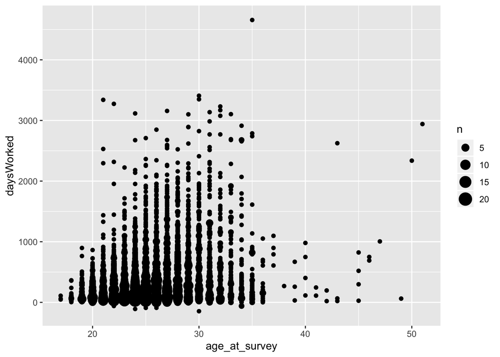

```r
ggplot(df2, aes(y=daysWorked, x=age_at_survey)) + geom_point() + geom_count()
```

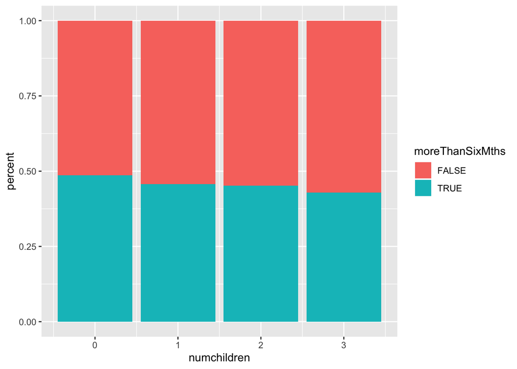

```r
df3_numchildren = group_by(df2, numchildren) %>% count(moreThanSixMths) %>% group_by(numchildren) %>% mutate(percent = n/sum(n))
ggplot(df3_numchildren, aes(y = percent, x = numchildren, fill = moreThanSixMths)) + geom_bar(stat="identity")
```

```r
df3_numearnincome = group_by(df2, numearnincome) %>% count(moreThanSixMths) %>% group_by(numearnincome) %>% mutate(percent = n/sum(n))
df3_numearnincome
```

```
## # A tibble: 19 x 4
## # Groups:   numearnincome [11]
##    numearnincome moreThanSixMths     n percent
##            <dbl> <fct>           <int>   <dbl>
##  1             0 FALSE            5113   0.536
##  2             0 TRUE             4432   0.464
##  3             1 FALSE            2063   0.498
##  4             1 TRUE             2077   0.502
##  5             2 FALSE             819   0.509
##  6             2 TRUE              790   0.491
##  7             3 FALSE             194   0.519
##  8             3 TRUE              180   0.481
##  9             4 FALSE              55   0.470
## 10             4 TRUE               62   0.530
## 11             5 FALSE              12   0.545
## 12             5 TRUE               10   0.455
## 13             6 FALSE               8   0.571
## 14             6 TRUE                6   0.429
## 15             7 FALSE               4   0.8
## 16             7 TRUE                1   0.2
## 17             8 TRUE                8   1
## 18             9 TRUE                1   1
## 19            10 FALSE               1   1
```

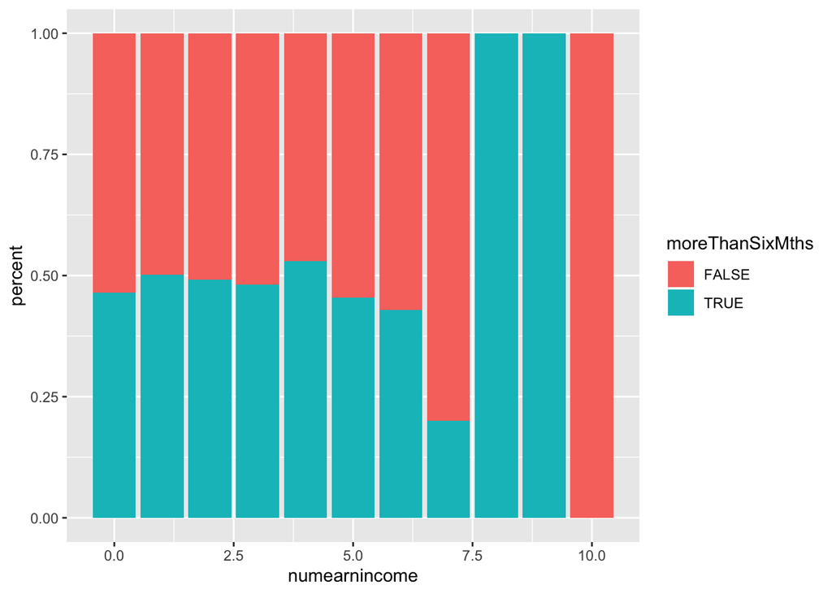

```r
ggplot(df3_numearnincome, aes(y = percent, x = numearnincome, fill = moreThanSixMths)) + geom_bar(stat="identity")
```

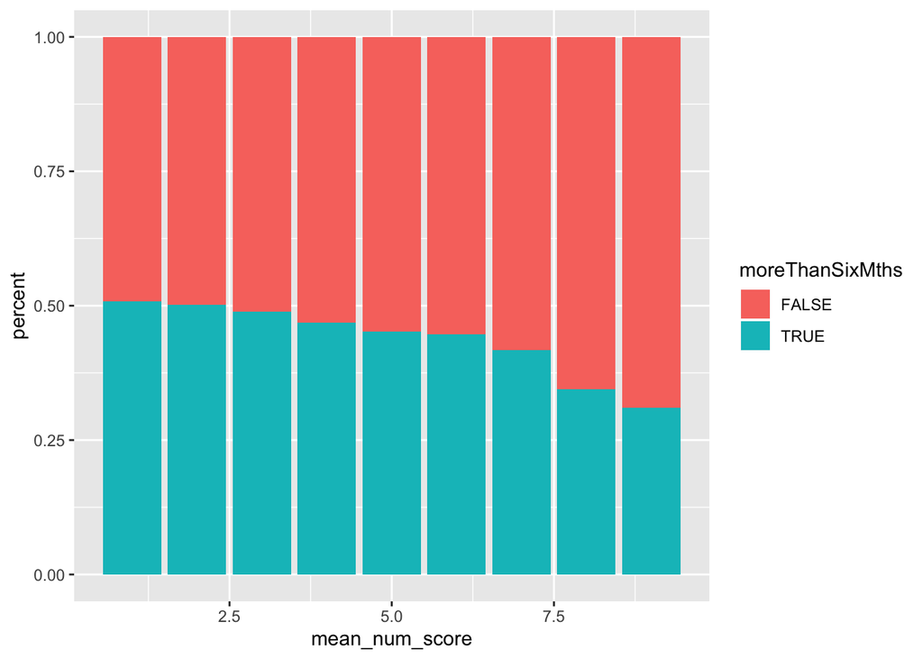

```r
df3_mean_num_score = group_by(df2, mean_num_score) %>% count(moreThanSixMths) %>% group_by(mean_num_score) %>% mutate(percent = n/sum(n))
ggplot(df3_mean_num_score, aes(y = percent, x = mean_num_score, fill = moreThanSixMths)) + geom_bar(stat="identity")
```

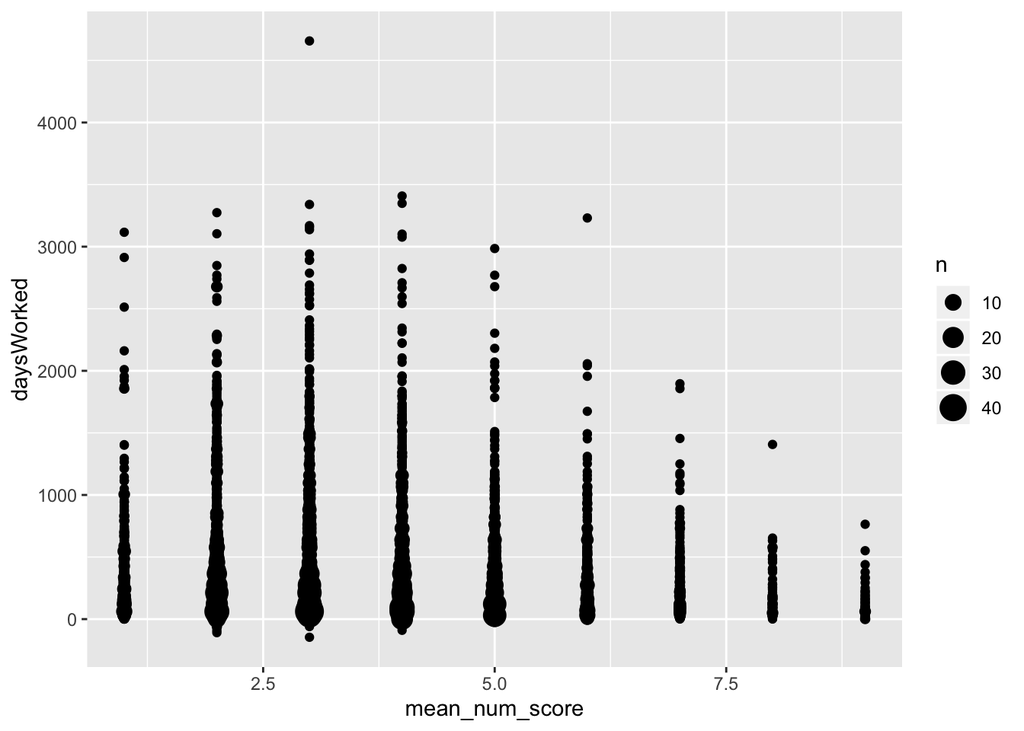

```r
ggplot(df2, aes(y=daysWorked, x=mean_num_score)) + geom_point() + geom_count()
```

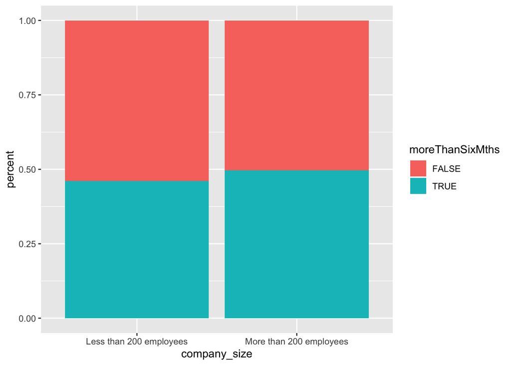

```r
df3_company_size = group_by(df2, company_size) %>% count(moreThanSixMths) %>% group_by(company_size) %>% mutate(percent = n/sum(n))
ggplot(df3_company_size, aes(y = percent, x = company_size, fill = moreThanSixMths)) + geom_bar(stat="identity")
```

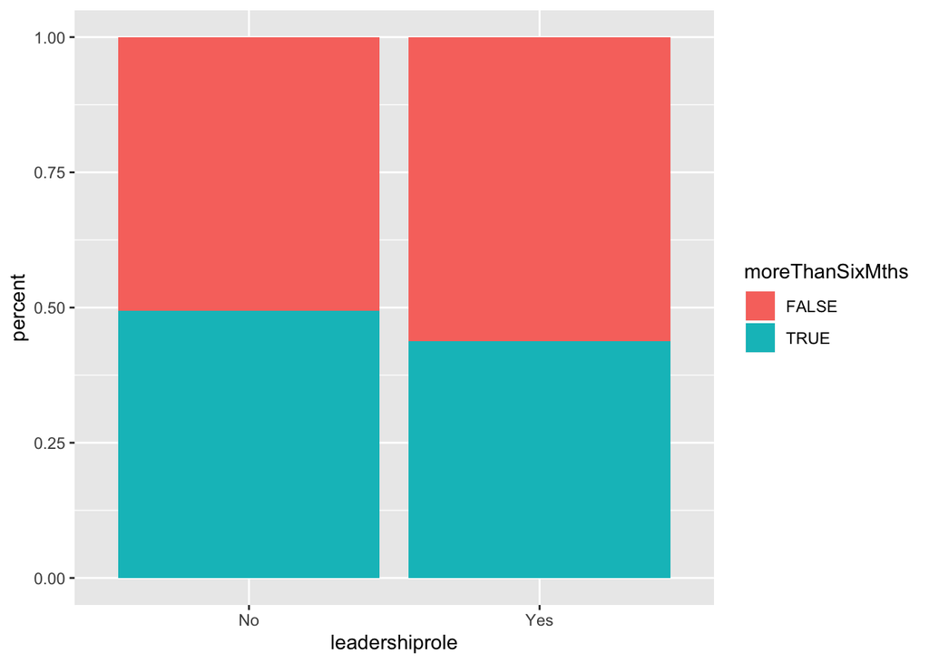

```r
df3_leadershiprole = group_by(df2, leadershiprole) %>% count(moreThanSixMths) %>% group_by(leadershiprole) %>% mutate(percent = n/sum(n))
ggplot(df3_leadershiprole, aes(y = percent, x = leadershiprole, fill = moreThanSixMths)) + geom_bar(stat="identity")
```

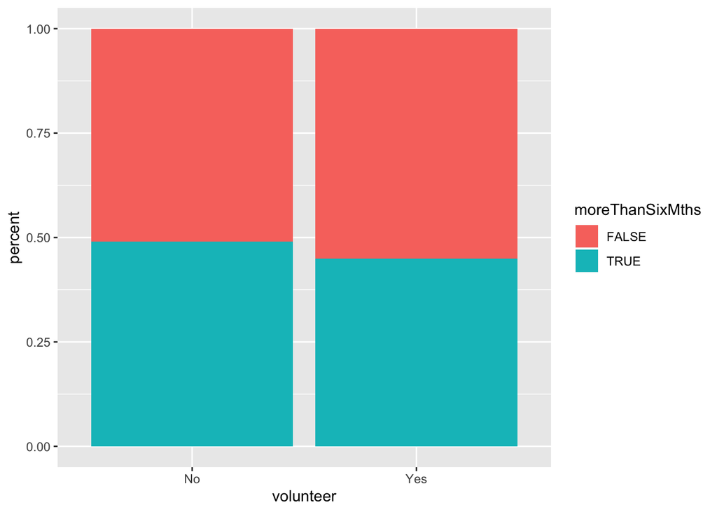

```r
df3_volunteer = group_by(df2, volunteer) %>% count(moreThanSixMths) %>% group_by(volunteer) %>% mutate(percent = n/sum(n))
ggplot(df3_volunteer, aes(y = percent, x = volunteer, fill = moreThanSixMths)) + geom_bar(stat="identity")
```

age at survey

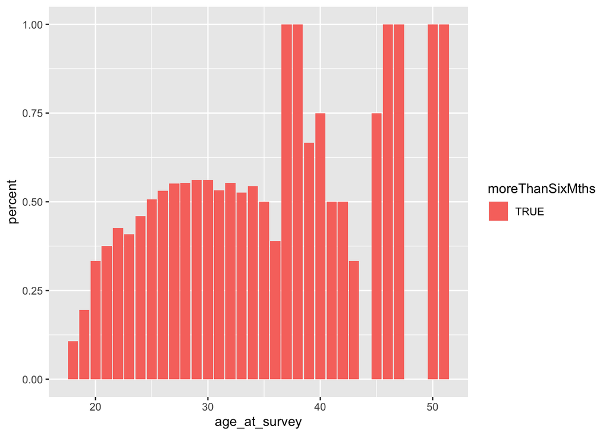

```r
df3_age_at_survey = group_by(df2, age_at_survey) %>% count(moreThanSixMths) %>% group_by(age_at_survey) %>% mutate(percent = n/sum(n))
df3_age_at_survey = filter(df3_age_at_survey, moreThanSixMths == T)
ggplot(df3_age_at_survey, aes(y = percent, x = age_at_survey, fill = moreThanSixMths)) + geom_bar(stat="identity")
```

## performing decision tree

```r
model.rpart <- train(moreThanSixMths ~ ., data = dfTrain, method = "rpart", trControl = TRAINCONTROL)
model.rpart
```

```
## CART
##
## 12670 samples
##    20 predictor
##     2 classes: 'FALSE', 'TRUE'
##
## No pre-processing
## Resampling: Cross-Validated (5 fold)
## Summary of sample sizes: 10135, 10136, 10136, 10136, 10137
## Resampling results across tuning parameters:
##
##   cp           Accuracy   Kappa
##   0.002477701  0.5812162  0.1529270
##   0.021473406  0.5737201  0.1449665
##   0.086223984  0.5350411  0.0453716
##
## Accuracy was used to select the optimal model using the largest value.
## The final value used for the model was cp = 0.002477701.
```

```r
# test model on training data
my_results.rpart <- predict(model.rpart, dfTest)

table(my_results.rpart, dfTest$moreThanSixMths)
```

```
##
## my_results.rpart FALSE TRUE
##            FALSE  1105  773
##            TRUE    548  740
```

```r
# make confusion table
confusionMatrix(table(my_results.rpart, dfTest$moreThanSixMths))
```

```
## Confusion Matrix and Statistics
##
##
## my_results.rpart FALSE TRUE
##            FALSE  1105  773
##            TRUE    548  740
##
##                Accuracy : 0.5828
##                  95% CI : (0.5654, 0.6)
##     No Information Rate : 0.5221
##     P-Value [Acc > NIR] : 4.137e-12
##
##                   Kappa : 0.1586
##
##  Mcnemar's Test P-Value : 7.135e-10
##
##             Sensitivity : 0.6685
##             Specificity : 0.4891
##          Pos Pred Value : 0.5884
##          Neg Pred Value : 0.5745
##              Prevalence : 0.5221
##          Detection Rate : 0.3490
##    Detection Prevalence : 0.5932
##       Balanced Accuracy : 0.5788
##
##        'Positive' Class : FALSE
##
```

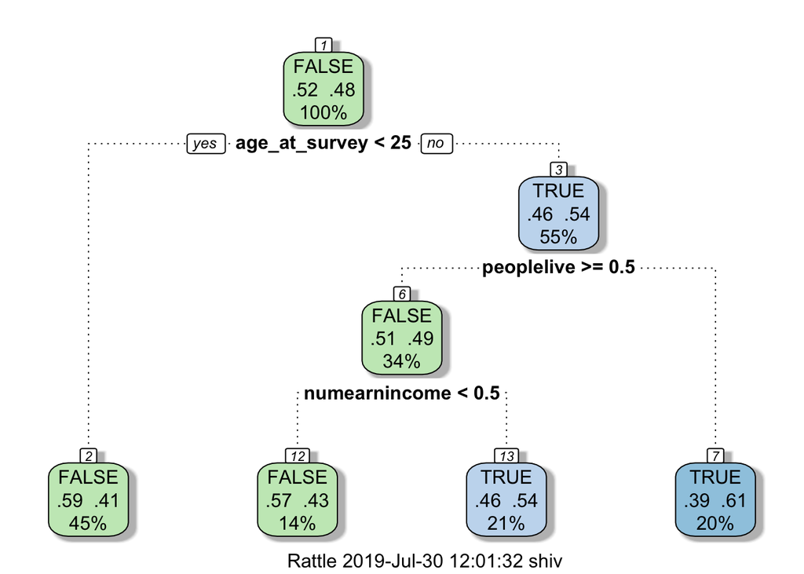

```r
fancyRpartPlot(model.rpart$finalModel)
```

Results for rpart: Accuracy : 0.5828  
Kappa : 0.1586 Sensitivity : 0.6685 Specificity : 0.4891